# Coursework_4

Harry Wright

7 Jan 2016

#### 1. SVM

**This problem involved the `OJ` data set which is part of the `ISLR` package.**

**a) Create a training set containing a random sample of 800 observations, and a test set containing the remaining observations.**

```r
library(ISLR)
set.seed(1)
train<-sample(nrow(OJ),800)
oj.train<-OJ[train,]
oj.test<-OJ[-train,]
```

**b) Fit a support vector classifier to the training data using `cost = 0.01`, with `Purchase` as the response and the other variables as predictors. Use the `summary()` function to produce summary statistics, and describe the results obtained.**

```r
library(e1071)
oj.svc<-svm(Purchase~.,data=oj.train,kernel="linear",cost=0.01)
summary(oj.svc)
```

```
##
## Call:
## svm(formula = Purchase ~ ., data = oj.train, kernel = "linear",
##     cost = 0.01)
##
##
## Parameters:
##    SVM-Type:  C-classification
##  SVM-Kernel:  linear
##        cost:  0.01
##       gamma:  0.05555556
##
## Number of Support Vectors:  432
##
##  ( 215 217 )
##
##
## Number of Classes:  2
##
## Levels:
##  CH MM
```

Results show there are 432 support vectors, 215 of which belong to CH, 217 to MM.

**c) What are the training and test error rates?**

```r
oj.svc.pred.train<-predict(oj.svc,oj.train)
table(oj.svc.pred.train,oj.train$Purchase)
```

```
##
## oj.svc.pred.train  CH  MM
##                CH 439  78
##                MM  55 228
```

```r
(78+55)/800
```

```
## [1] 0.16625
```

Training error rate is 16.6%.

```r
oj.svc.pred.test<-predict(oj.svc,oj.test)
table(oj.svc.pred.test,oj.test$Purchase)
```

```
##
## oj.svc.pred.test  CH  MM
##               CH 141  31
##               MM  18  80
```

```r
(18+31)/270
```

```
## [1] 0.1814815
```

Test error rate is 18.1%.

**d) Use the `tune()` function to select an optimal `cost`. Consider values in the range of 0.01 to 10.**

```r
set.seed(1)
oj.tune<-tune(svm,Purchase~.,data=oj.train,kernel="linear",ranges=list(cost=c(0.01,0.05,0.1,0.5,1,5,10)))
summary(oj.tune)
```

```
##
## Parameter tuning of 'svm':
##
## - sampling method: 10-fold cross validation
##
## - best parameters:
##  cost
##  0.05
##
## - best performance: 0.17125
##
## - Detailed performance results:
##    cost   error dispersion
## 1  0.01 0.17500 0.03996526
## 2  0.05 0.17125 0.03682259
## 3  0.10 0.17875 0.03821086
## 4  0.50 0.17625 0.03747684
## 5  1.00 0.17750 0.03717451
## 6  5.00 0.17875 0.03537988
## 7 10.00 0.18000 0.04005205
```

From the results, optimal cost is 0.05, as it has the lowest error rate at 17.1%

**e) Compute the training and test error rates using this new value for `cost`.**

```r
oj.svc<-svm(Purchase~.,data=oj.train,kernel="linear",cost=0.05)
oj.svc.pred.train<-predict(oj.svc,oj.train)
table(oj.svc.pred.train,oj.train$Purchase)
```

```
##
## oj.svc.pred.train  CH  MM
##                CH 436  71
##                MM  58 235
```

```r
(71+58)/800
```

```
## [1] 0.16125
```

Training error rate is 16.1%.

```r
oj.svc.pred.test<-predict(oj.svc,oj.test)
table(oj.svc.pred.test,oj.test$Purchase)
```

```
##
## oj.svc.pred.test  CH  MM
##               CH 139  31
##               MM  20  80
```

```r
(20+31)/270
```

```
## [1] 0.1888889
```

Test error rate is 18.9%.

**f) Repeat parts b) through e) using a support vector machine with radial kernel. Use the default value for `gamma`.**

```r
oj.svm<-svm(Purchase~.,data=oj.train,kernel="radial",cost=0.01)
summary(oj.svm)
```

```
##
## Call:
## svm(formula = Purchase ~ ., data = oj.train, kernel = "radial",
##     cost = 0.01)
##
##
## Parameters:
##    SVM-Type:  C-classification
##  SVM-Kernel:  radial
##        cost:  0.01
##       gamma:  0.05555556
##
## Number of Support Vectors:  617
##
##  ( 306 311 )
##
##
## Number of Classes:  2
##
## Levels:
##  CH MM
```

Results show there are 617 support vectors, 306 of which belong to CH, 311 to MM.

```r
oj.svm.pred.train<-predict(oj.svm,oj.train)
table(oj.svm.pred.train,oj.train$Purchase)
```

```
##
## oj.svm.pred.train  CH  MM
##                CH 494 306
##                MM   0   0
```

```r
306/800
```

```
## [1] 0.3825
```

Training error rate is 38.3%.

```r
oj.svm.pred.test<-predict(oj.svm,oj.test)
table(oj.svm.pred.test,oj.test$Purchase)
```

```
##
## oj.svm.pred.test  CH  MM
##               CH 159 111
##               MM   0   0
```

```r
111/270
```

```
## [1] 0.4111111
```

Test error rate is 41.1%.

```r
set.seed(1)
oj.tune<-tune(svm,Purchase~.,data=oj.train,kernel="radial",ranges=list(cost=c(0.01,0.05,0.1,0.5,1,5,10)))
summary(oj.tune)
```

```
##
## Parameter tuning of 'svm':
##
## - sampling method: 10-fold cross validation
##
## - best parameters:
##  cost
##   0.5
##
## - best performance: 0.17
##
## - Detailed performance results:
##    cost   error dispersion
## 1  0.01 0.38250 0.05596378
## 2  0.05 0.22125 0.07431399
## 3  0.10 0.17875 0.04168749
## 4  0.50 0.17000 0.04721405
## 5  1.00 0.17500 0.04750731
## 6  5.00 0.17375 0.04875178
## 7 10.00 0.18250 0.04866267
```

From the results, optimal cost is 0.5, as it has the lowest error rate at 17%.

```r
oj.svm<-svm(Purchase~.,data=oj.train,kernel="radial",cost=0.5)
oj.svm.pred.train<-predict(oj.svm,oj.train)
table(oj.svm.pred.train,oj.train$Purchase)
```

```
##
## oj.svm.pred.train  CH  MM
##                CH 453  77
##                MM  41 229
```

```r
(77+41)/800
```

```
## [1] 0.1475
```

Training error rate is 14.8%.

```r
oj.svm.pred.test<-predict(oj.svm,oj.test)
table(oj.svm.pred.test,oj.test$Purchase)
```

```
##
## oj.svm.pred.test  CH  MM
##               CH 143  29
##               MM  16  82
```

```r
(29+16)/270
```

```
## [1] 0.1666667
```

Test error rate is 16.7%.

**g) Repeat parts b) through e) using a support vector machine with a polynomial kernel. Set `degree = 2`.**

```r
oj.svm<-svm(Purchase~.,data=oj.train,degree=2,kernel="polynomial",cost=0.01)
summary(oj.svm)
```

```
##
## Call:
## svm(formula = Purchase ~ ., data = oj.train, degree = 2, kernel = "polynomial",
##     cost = 0.01)
##
##
## Parameters:
##    SVM-Type:  C-classification
##  SVM-Kernel:  polynomial
##        cost:  0.01
##      degree:  2
##       gamma:  0.05555556
##      coef.0:  0
##
## Number of Support Vectors:  620
##
##  ( 306 314 )
##
##
## Number of Classes:  2
##
## Levels:
##  CH MM
```

Results show there are 620 support vectors, 306 of which belong to CH, 314 to MM.

```r
oj.svm.pred.train<-predict(oj.svm,oj.train)
table(oj.svm.pred.train,oj.train$Purchase)
```

```
##
## oj.svm.pred.train  CH  MM
##                CH 494 306
##                MM   0   0
```

```r
306/800
```

```
## [1] 0.3825
```

Training error rate is 38.3%.

```r
oj.svm.pred.test<-predict(oj.svm,oj.test)
table(oj.svm.pred.test,oj.test$Purchase)
```

```
##
## oj.svm.pred.test  CH  MM
##               CH 159 111
##               MM   0   0
```

```r
111/270
```

```
## [1] 0.4111111
```

Test error rate is 41.1%.

```r
set.seed(1)
oj.tune<-tune(svm,Purchase~.,data=oj.train,kernel="polynomial",degree=2,ranges=list(cost=c(0.01,0.05,0.1,0.5,1,5,10)))
summary(oj.tune)
```

```
##
## Parameter tuning of 'svm':
##
## - sampling method: 10-fold cross validation
##
## - best parameters:
##  cost
##     5
##
## - best performance: 0.1725
##
## - Detailed performance results:
##    cost   error dispersion
## 1  0.01 0.38250 0.05596378
## 2  0.05 0.34750 0.06174545
## 3  0.10 0.32375 0.06303934
## 4  0.50 0.20625 0.05472469
## 5  1.00 0.19125 0.04860913
## 6  5.00 0.17250 0.05737305
## 7 10.00 0.17875 0.05653477
```

From the results, optimal cost is 5, as it has the lowest error rate at 17.25%.

```r
oj.svm<-svm(Purchase~.,data=oj.train,degree=2,kernel="polynomial",cost=5)
oj.svm.pred.train<-predict(oj.svm,oj.train)
table(oj.svm.pred.train,oj.train$Purchase)
```

```
##
## oj.svm.pred.train  CH  MM
##                CH 454  79
##                MM  40 227
```

```r
(40+79)/800
```

```
## [1] 0.14875
```

Training error rate is 14.9%.

```r
oj.svm.pred.test<-predict(oj.svm,oj.test)
table(oj.svm.pred.test,oj.test$Purchase)
```

```
##
## oj.svm.pred.test  CH  MM
##               CH 142  32
##               MM  17  79
```

```r
(17+32)/270
```

```
## [1] 0.1814815
```

Test error rate is 18.1%.

**h) Overall, which approach seems to give the best results on this data?**

- SVC
  - Cost = 0.01
    - Train = 16.6%
    - Test = 18.1%
  - Cost = 0.05
    - Train = 16.1%
    - Test = 18.9%
- SVM Radial
  - Cost = 0.01
    - Train = 38.3%
    - Test = 41.1%
  - Cost = 0.5
    - Train = 14.8%
    - Test = 16.7%
- SVM Polynomial (degree = 2)
  - Cost = 0.01
    - Train = 38.3%
    - Test = 41.1%
  - Cost = 5
    - Train = 14.9%
    - Test = 18.1%

As shown in the overview of results above, the SVM with radial kernel (using cost = 0.5) gives the best results as it achieves the lowest error rates.

#### 2. SVM and Logistic Regression

**We have seen that we can fit an SVM with a non-linear kernel in order to perform classification using a non-linear decision boundary. We will now see that we can also obtain a non-linear decision boundary by performing logistic regression using non-linear transformations of the features.**

**a) Generate a data set with `n=500` and `p=2`, such that the observations belong to two classes with a quadratic decision boundary between them.**

```r
set.seed(1)
X1<-runif(500)-0.5
X2<-runif(500)-0.5
Y<-1*(X1^2-X2^2>0)
dataframe<-data.frame(X1=X1,X2=X2,Y=Y)
```

**b) Plot the observations, coloured according to their class labels. Your plot should display `X1` on the x-axis and `X2` on the y-axis.**

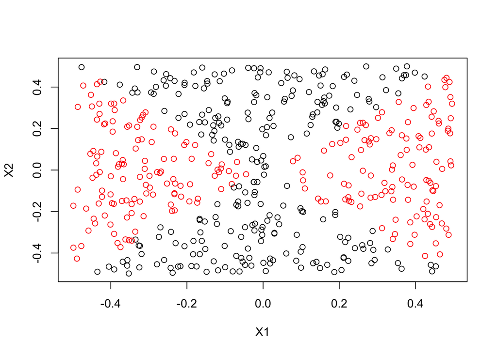

```r
plot(X1,X2,xlab="X1",ylab="X2",col=Y+1)
```

**c) Fit a logistic regression model to the data, using `X1` and `X2` as the predictors.**

```r
logres<-glm(Y~.,data=dataframe,family=binomial)
summary(logres)
```

```
##
## Call:
## glm(formula = Y ~ ., family = binomial, data = dataframe)
##
## Deviance Residuals:
##    Min      1Q  Median      3Q     Max
## -1.179  -1.139  -1.112   1.206   1.257
##
## Coefficients:
##              Estimate Std. Error z value Pr(>|z|)
## (Intercept) -0.087260   0.089579  -0.974    0.330
## X1           0.196199   0.316864   0.619    0.536
## X2          -0.002854   0.305712  -0.009    0.993
##
## (Dispersion parameter for binomial family taken to be 1)
##
##     Null deviance: 692.18  on 499  degrees of freedom
## Residual deviance: 691.79  on 497  degrees of freedom
## AIC: 697.79
##
## Number of Fisher Scoring iterations: 3
```

**d) Apply this model to the *training data* in order to obtain a predicted class label for each training observation. Plot the observations, coloured according to the *predicted* class labels. The decision boundary should be linear.**

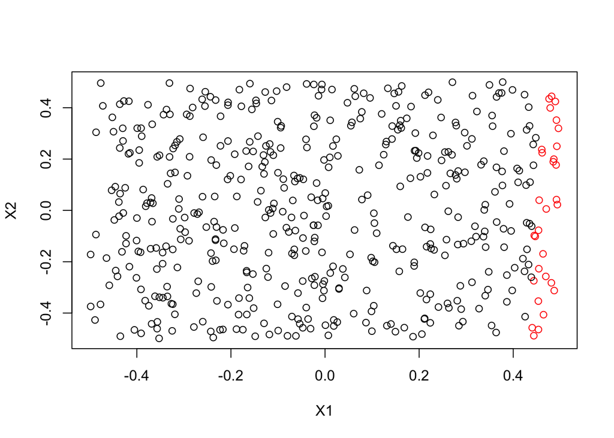

```r
probability<-predict(logres,type="response")
prediction<-rep(0,nrow(dataframe))
prediction[probability>.5]<-1
plot(X1,X2,xlab="X1",ylab="X2",col=prediction+1)
```

**e) Now fit a logistic regression model to the data using non-linear functions of `X1` and `X2` as predictors.**

```r
logres<-glm(Y~poly(X1,2)+poly(X2,2),data=dataframe,family=binomial)
summary(logres)
```

```
##
## Call:
## glm(formula = Y ~ poly(X1, 2) + poly(X2, 2), family = binomial,
##     data = dataframe)
##
## Deviance Residuals:
##        Min          1Q      Median          3Q         Max
## -1.079e-03  -2.000e-08  -2.000e-08   2.000e-08   1.297e-03
##
## Coefficients:
##               Estimate Std. Error z value Pr(>|z|)
## (Intercept)     -94.48    2963.78  -0.032    0.975
## poly(X1, 2)1   3442.52  104411.28   0.033    0.974
## poly(X1, 2)2  30110.74  858421.66   0.035    0.972
## poly(X2, 2)1    162.82   26961.99   0.006    0.995
## poly(X2, 2)2 -31383.76  895267.48  -0.035    0.972
##
## (Dispersion parameter for binomial family taken to be 1)
##
##     Null deviance: 6.9218e+02  on 499  degrees of freedom
## Residual deviance: 4.2881e-06  on 495  degrees of freedom
## AIC: 10
##
## Number of Fisher Scoring iterations: 25
```

**f) Apply this model to the *training data* in order to obtain a predicted class label for each training observation. Plot the observations, colored according to the *predicted* class labels. The decision boundary should obvioulsy be non-linear. If it is not, then repeat a)-e) until you come up with an example in which the predicted class labels are obviously non-linear.**

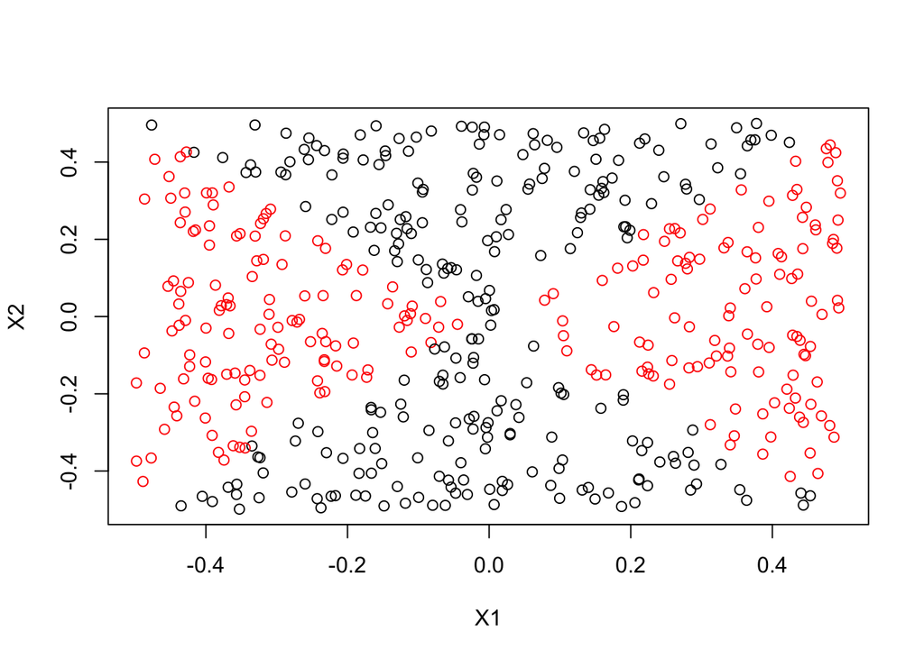

```r
probability<-predict(logres,type="response")
prediction<-rep(0,nrow(dataframe))
prediction[probability>.5]<-1
plot(X1,X2,xlab="X1",ylab="X2",col=prediction+1)
```

**g) Fit a support vector classifier to the data with `X1` and `X2` as predictors. Obtain a class prediction for each training observation. Plot the observations, coloured according to the *predicted class labels*.**

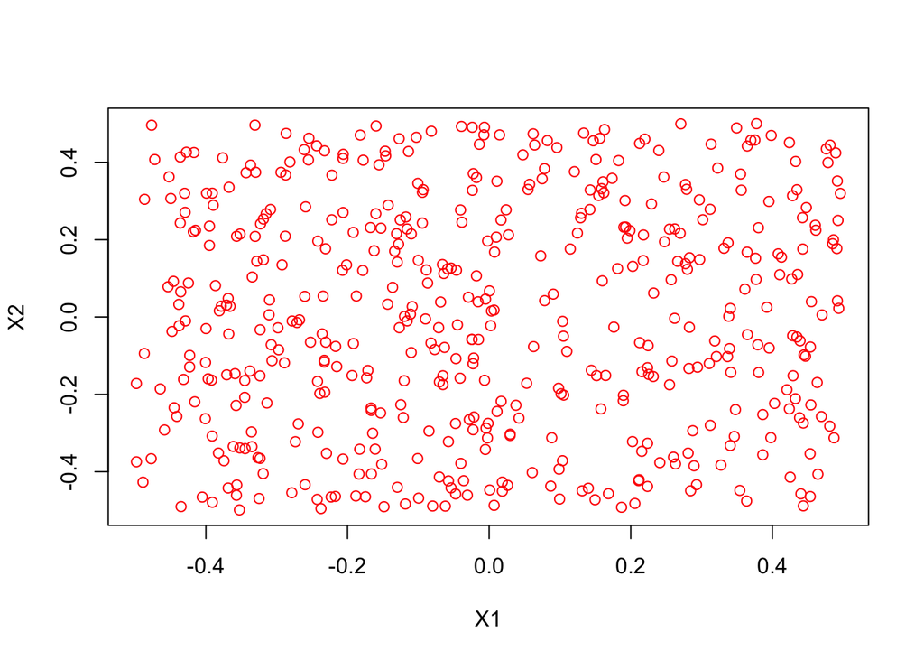

```r
svc<-svm(as.factor(Y)~.,data=dataframe,kernel="linear")
prediction<-predict(svc,dataframe)
plot(X1,X2,xlab="X1",ylab="X2",col=as.integer(prediction)+1)
```

**h) Fit an SVM using a non-linear kernel to the data with `X1` and `X2` as predictors. Obtain a class prediction for each training observation. Plot the observations, coloured according to the *predicted class labels*.**

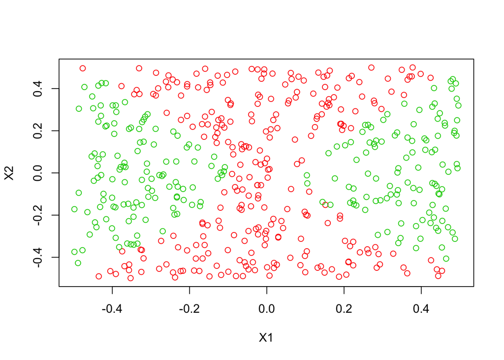

```r
my.svm<-svm(as.factor(Y)~.,data=dataframe,kernel="radial")
prediction<-predict(my.svm,dataframe)
plot(X1,X2,xlab="X1",ylab="X2",col=as.integer(prediction)+1)
```

**i) Comment on your results.**

It is clear that using a linear model to predict the correct result is not an accurate method. A great improvement is seen when either modelling with an SVM with radial kernel or logistic regression using non-linear predictors.

#### 3. Hierarchical Clustering

**Consider the `USArrests data. We will now perform heirarchical clustering on the states.**

**a) Using heirarchical clustering with complete linkage and Euclidean distance, cluster the states**

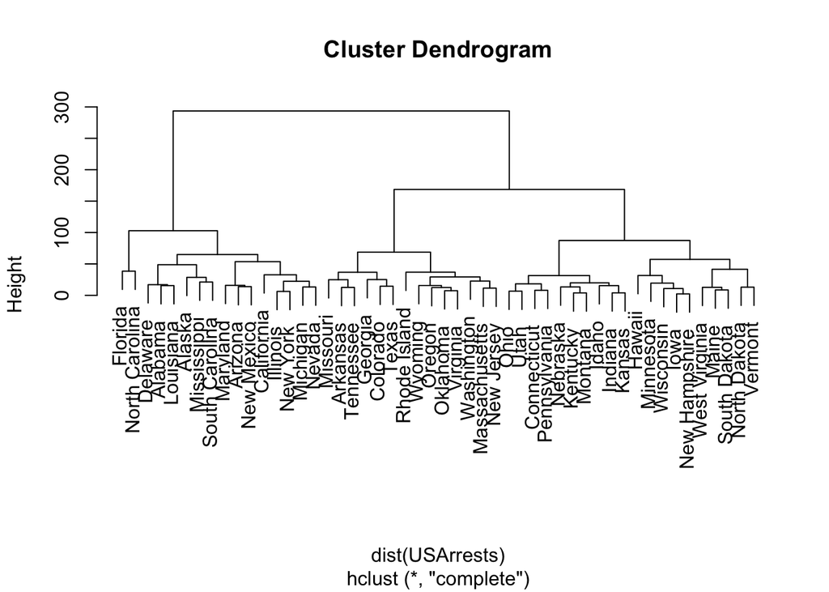

```r
usa.complete<- hclust(dist(USArrests),method="complete")
plot(usa.complete)
```

**b) Cut the dendrogram at a height that results in three distinct clusters. Which states belong to which clusters?**

```r
cutree(usa.complete,k=3)
```

```
##        Alabama         Alaska        Arizona       Arkansas     California
##              1              1              1              2              1
##       Colorado    Connecticut       Delaware        Florida        Georgia
##              2              3              1              1              2
##         Hawaii          Idaho       Illinois        Indiana           Iowa
##              3              3              1              3              3
##         Kansas       Kentucky      Louisiana          Maine       Maryland
##              3              3              1              3              1
##  Massachusetts       Michigan      Minnesota    Mississippi       Missouri
##              2              1              3              1              2
##        Montana       Nebraska         Nevada  New Hampshire     New Jersey
##              3              3              1              3              2
##     New Mexico       New York North Carolina   North Dakota           Ohio
##              1              1              1              3              3
##       Oklahoma         Oregon   Pennsylvania   Rhode Island South Carolina
##              2              2              3              2              1
##   South Dakota      Tennessee          Texas           Utah        Vermont
##              3              2              2              3              3
##       Virginia     Washington  West Virginia      Wisconsin        Wyoming
##              2              2              3              3              2
```

**c) Hierachically cluster the states using complete linkage and Euclidean distance, after scaling the variables to have standard deviation one.**

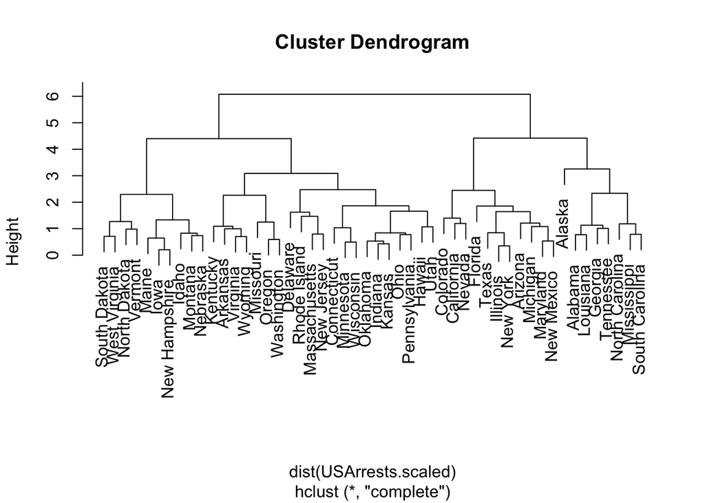

```r
USArrests.scaled<-scale(USArrests)
usa.complete.scaled<- hclust(dist(USArrests.scaled),method="complete")
plot(usa.complete.scaled)
```

**d) What effect does scaling the variables have on the hierarchical clustering obtained? In your opinion, should the variables be scaled before the inter-observation dissimilarities are computed? Provide a justification for your answer.**

Scaling the variables has the effect of reducing the dissimilarity between variables, which we can see by the drastically reduced range of `Height`.

The variables should be scaled before the inter-observation dissimilarities are computed as the variables are measured on different scales. Scaling before dissimilarties are computed will give each variable equal importance in the hierarchical clustering performed.

#### 4. PCA and K-Means Clustering

**In this problem, you will generate simulated data, and then perform PCA and K-Means clustering on the data.**

**a) Generate a simulated data set with 20 observations in each of three classes (i.e. 60 observations total), and 50 variables.**

```r
set.seed(1)
nvar<-50
sim<-matrix(rnorm(60*nvar),ncol=nvar)
for(i in 1:nvar) {
  sim[1:20,i]<-sim[1:20,i]+4
}
for(i in 1:nvar) {
  sim[41:60,i]<-sim[41:60,i]-4
}
sim.frame<-data.frame(sim)
```

**b) Perform PCA on the 60 observations and plot the first two principal components’ eigenvector. Use a different colour to indicate the observations in each of the three classes. If the three classes appear separated in this plot, then continue on to part (c). If not, the return to part (a) and modify the simulation so that there is greater separation between the three classes. Do not continue to part (c) until the three classes show at least some separation in the first two principal component eigenvectors.**

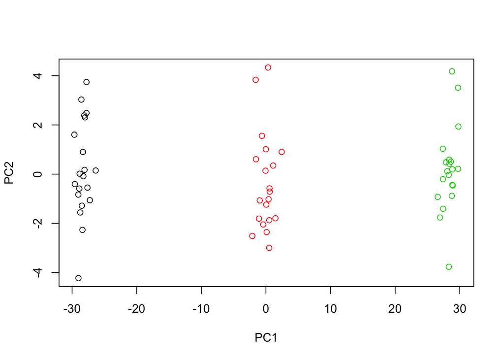

```r
sim.pca<-prcomp(sim.frame)
colours<-c(rep(1,20),rep(2,20),rep(3,20))
plot(sim.pca$x[,1:2],col=colours)
```

**c) Perform K-means clustering of the observations with K=3. How well do the clusters that you obtained in K-means clustering compare to the true class labels?**

```r
kmeans.result<-kmeans(sim.frame,centers=3,nstart=20)
table(kmeans.result$cluster,colours)
```

```
##    colours
##      1  2  3
##   1 20  0  0
##   2  0  0 20
##   3  0 20  0
```

It looks like the clusters were detected.